# 18_skill_variables

Joanna Schroeder

9/28/2020

```r
# function for data profiling
data_profiling <- function(df){
summary_table <- tibble(var = names(df),
       variable_type = map_chr(.x = df, .f = function(col) class(x = col)),
       num_unique = map_int(.x = df, .f = function(col) length(x = unique(x = col))),
       num_missing = map_int(.x = df, .f = function(col) sum(x = is.na(x = col)))) %>%
  mutate(perc_missing = round(100 * (x = num_missing / nrow(df)), digits = 2L))
return(summary_table)
}
```

## Purpose

We are interested in returning to the BGT tables to add covariates to our analysis. Here we explore the skill variables, which are in the skills table.

## Profiling

Here we profile the geographic subset of the BGT data for the DC MSA. The skills table is big. For the DC MSA there are there are 21591463 rows of data and 650702 unique ids, for an average of 33.181799 skills per person.

```r
#remove duplicate id column
skill <- skill[,-1]

data_profiling(skill)
```

```
## # A tibble: 8 x 5
##   var           variable_type num_unique num_missing perc_missing
##   <chr>         <chr>              <int>       <int>        <dbl>
## 1 skillid       integer            14161           0          0
## 2 skill         character          14165           0          0
## 3 cluster       character            656     4381757         20.3
## 4 clusterfamily character             29     4381757         20.3
## 5 isbaseline    logical                2           0          0
## 6 issoftware    logical                2           0          0
## 7 isspecialized logical                2           0          0
## 8 id            integer           650702           0          0
```

```r
head(skill, 20)
```

```
##    skillid           skill cluster clusterfamily isbaseline issoftware
## 1    10076          Repair    <NA>          <NA>      FALSE      FALSE
## 2    14604       Listening    <NA>          <NA>       TRUE      FALSE
## 3      850      Leadership    <NA>          <NA>       TRUE      FALSE
## 4     2524 Public Speaking    <NA>          <NA>      FALSE      FALSE
## 5    10076          Repair    <NA>          <NA>      FALSE      FALSE
## 6    12088 Microsoft Excel    <NA>          <NA>       TRUE       TRUE
## 7      421  Microsoft Word    <NA>          <NA>       TRUE       TRUE
## 8     5677          OS/390    <NA>          <NA>      FALSE       TRUE
## 9    11748           SPUFI    <NA>          <NA>      FALSE       TRUE
## 10   13311         English    <NA>          <NA>       TRUE      FALSE
## 11    9772        Planning    <NA>          <NA>       TRUE      FALSE
## 12   17350     Google Apps    <NA>          <NA>      FALSE       TRUE
## 13    3932   Multi-Tasking    <NA>          <NA>       TRUE      FALSE
## 14    5327        Cleaning    <NA>          <NA>      FALSE      FALSE
```

[output cut: 27 more lines]

```r
skill %>% filter(isbaseline == TRUE) %>% mutate(n = n()) %>% summarise(percent = n/21591463) %>% distinct()
```

```
##     percent
## 1 0.1913593
```

```r
skill %>% mutate(total = n()) %>% filter(isbaseline == TRUE) %>% group_by(skill) %>% mutate(n = n()) %>% summarise(percent = (n/total)*100) %>% distinct() %>% arrange(-percent)
```

```
## # A tibble: 139 x 2
## # Groups:   skill [139]
##    skill                    percent
##    <chr>                      <dbl>
##  1 Microsoft Excel            1.31
##  2 Microsoft Office           1.23
##  3 Research                   1.14
##  4 Organizational Skills      1.00
##  5 Microsoft Powerpoint       0.951
##  6 Planning                   0.914
##  7 Communication Skills       0.899
##  8 Microsoft Word             0.829
##  9 Writing                    0.643
## 10 Teamwork / Collaboration   0.624
## # … with 129 more rows
```

```r
skill %>% mutate(total = n()) %>% filter(issoftware == TRUE) %>% mutate(n = n()) %>% summarise(percent = n/total) %>% distinct()
```

```
##     percent
## 1 0.2423087
```

```r
skill %>% mutate(total = n()) %>% filter(issoftware == TRUE) %>% group_by(skill) %>% mutate(n = n()) %>% summarise(percent = (n/total)*100) %>% distinct() %>% arrange(-percent)
```

```
## # A tibble: 1,930 x 2
## # Groups:   skill [1,930]
##    skill                percent
##    <chr>                  <dbl>
##  1 Microsoft Excel        1.31
##  2 Microsoft Office       1.23
##  3 Microsoft Powerpoint   0.951
##  4 Microsoft Word         0.829
##  5 Microsoft Windows      0.603
##  6 Microsoft Access       0.507
##  7 SQL                    0.484
##  8 Oracle                 0.431
##  9 UNIX                   0.348
## 10 Java                   0.332
## # … with 1,920 more rows
```

```r
skill %>% mutate(total = n()) %>% filter(isspecialized == TRUE) %>% mutate(n = n()) %>% summarise(percent = n/total) %>% distinct()
```

```
##     percent
## 1 0.8083926
```

```r
skill %>% mutate(total = n()) %>% filter(isspecialized == TRUE) %>% group_by(skill) %>% mutate(n = n()) %>% summarise(percent = (n/total)*100) %>% distinct() %>% arrange(-percent)
```

```
## # A tibble: 14,025 x 2
## # Groups:   skill [14,025]
##    skill                  percent
##    <chr>                    <dbl>
##  1 Customer Service         1.00
##  2 Budgeting                0.981
##  3 Scheduling               0.885
##  4 Project Management       0.766
##  5 Sales                    0.643
##  6 Staff Management         0.585
##  7 Hardware Experience      0.580
##  8 Administrative Support   0.562
##  9 SQL                      0.484
## 10 Accounting               0.447
## # … with 14,015 more rows
```

```r
skill %>% mutate(total = n()) %>% group_by(clusterfamily) %>% mutate(n = n()) %>% summarise(percent = (n/total) * 100) %>% distinct() %>% arrange(-percent)
```

```
## # A tibble: 29 x 2
## # Groups:   clusterfamily [29]
##    clusterfamily                  percent
##    <chr>                            <dbl>
##  1 Information Technology           28.9
##  2 <NA>                             20.3
##  3 Business                          7.87
##  4 Finance                           6.31
##  5 Administration                    4.73
##  6 Health Care                       4.46
##  7 Sales                             3.20
##  8 Marketing and Public Relations    3.05
##  9 Customer and Client Support       2.22
## 10 Design                            2.21
## # … with 19 more rows
```

```r
skill %>% mutate(total = n()) %>% group_by(cluster) %>% mutate(n = n()) %>% summarise(percent = (n/total) * 100) %>% distinct() %>% arrange(-percent)
```

```
## # A tibble: 656 x 2
## # Groups:   cluster [656]
##    cluster                                   percent
##    <chr>                                       <dbl>
##  1 <NA>                                        20.3
##  2 Microsoft Office and Productivity Tools      3.77
##  3 Basic Customer Service                       1.78
##  4 Operating Systems                            1.64
##  5 General Administrative and Clerical Tasks    1.61
##  6 Technical Support                            1.39
##  7 Graphic and Visual Design Software           1.31
##  8 System Design and Implementation             1.30
##  9 Administrative Support                       1.28
## 10 Budget Management                            1.15
## # … with 646 more rows
```

The skills data is relatively complete because it is mostly imputed data. The cluster and clusterfamily variables are the most incomplete, with about 20% missing.

About 20% of the skills are designated as "baseline" skills, which appear to be soft skills. About 24% of skills are "software" skills, which includes Microsoft office. About 80% of skills are "specialized".

The cluster and clusterfamily variables group skills into categories. The most common clusterfamily is information technology, which is not surprising given the nature of the Burning Glass Data. The most commmon cluster is Microsoft Office.

## Comparing nonveterans and veterans

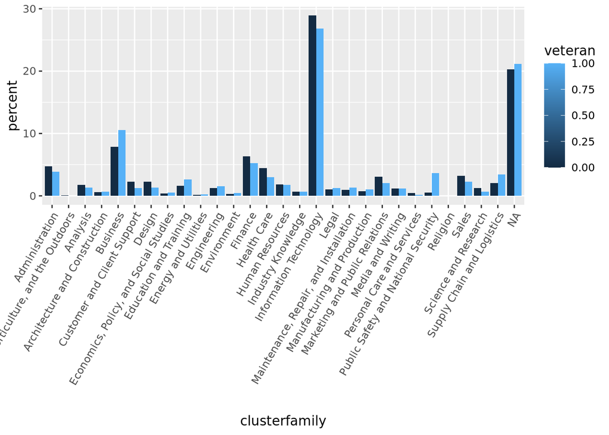

```r
bg_vet_demographic <- read.csv("~/git/DSPG2020/career/data/02_bg_vet_demographic.csv")

ids <- bg_vet_demographic$id

skill <- skill %>% mutate(veteran = ifelse(id %in% ids, 1, 0))

skill %>% group_by(veteran) %>% mutate(total = n()) %>% group_by(veteran, clusterfamily) %>% mutate(n = n()) %>% mutate(percent = round(n/total * 100, 2)) %>% select(veteran, clusterfamily, percent) %>% distinct() %>%
  ggplot(aes(x = clusterfamily, y = percent, group = veteran, fill = veteran)) +
  geom_col(position = "dodge") +
  theme(axis.text.x = element_text(angle = 60, hjust = 1))
```

```r
skill %>% group_by(id) %>% mutate(n = n()) %>% arrange(id) %>% ungroup() %>% group_by(veteran) %>% summarise(mean = mean(n), median = median(n))
```

```
## # A tibble: 2 x 3
##   veteran  mean median
##     <dbl> <dbl>  <dbl>
## 1       0  63.3     43
## 2       1  62.1     39
```